# Project: Investigating No-show appointments

- Introduction
- Data Wrangling
- Data Assessment
- Data Cleaning
- Exploratory Data Analysis
- Does gender affect if the patient will show up for scheduled appointment?
- Does patients who wait less for their appointments show up to their appointments more?
- Does age affect if the patient will show up for scheduled appointment?
- Does being handicapped affect if the patient will show up for scheduled appointment?
- what about other factors such as (scholarship, hypertension, diabetes, alcoholic, reminder SMS)
- Conclusions
- Conclusions
- Limitations

## Introduction

#### Questions

> This report investigates the factors are may affect if the patient will show up for their scheduled appointment?

> Mainly this report will tackle the following questions
> - Does gender affect if the patient will show up for scheduled appointment?
> - Does patients who wait less for their appointments show up to their appointments more?
> - Does age affect if the patient will show up for scheduled appointment?
> - Does being handicapped affect if the patient will show up for scheduled appointment?
> - what about other factors such as (scholarship, hypertension, diabetes, alcoholic, reminder SMS)

#### Setting up the environment

```python
import numpy as np
import pandas as pd
import matplotlib.pyplot as plt
import seaborn as sns

%matplotlib inline

#Load the Data
df = pd.read_csv('./noshowappointments-kagglev2-may-2016.csv')
```

```python
def get_percentage (df, column):
    """
    It takes a dataframe and a column name as input, and returns the percentage of patients who showed up for their appointment, grouped by the column specified.

    :param df: the dataframe
    :param column: the column you want to get the percentage of
    :return: The percentage of patients who showed up for their appointment, grouped by the column specified.

    for example if column is "scholarship":

        no_show             scholarship
        0 (did show up)       0              80.192844
                              1              76.263696
        1 (didn't show up)    0              19.807156
                              1              23.736304

    """
    count = df.groupby(['no_show', column]).count()['patientid']
    totals = df.groupby(column).count()['patientid']
    fraction = count/totals
    return fraction*100
```

## Data Wrangling

> In this section of the report:
> - Assessment and building intuition
> - Cleaning Data

#### Assessment of Data

```python
df.head()
```

|  | PatientId | AppointmentID | Gender | ScheduledDay | AppointmentDay | Age | Neighbourhood | Scholarship | Hipertension | Diabetes | Alcoholism | Handcap | SMS_received | No-show |
| --- | --- | --- | --- | --- | --- | --- | --- | --- | --- | --- | --- | --- | --- | --- |
| 0 | 2.987250e+13 | 5642903 | F | 2016-04-29T18:38:08Z | 2016-04-29T00:00:00Z | 62 | JARDIM DA PENHA | 0 | 1 | 0 | 0 | 0 | 0 | No |
| 1 | 5.589978e+14 | 5642503 | M | 2016-04-29T16:08:27Z | 2016-04-29T00:00:00Z | 56 | JARDIM DA PENHA | 0 | 0 | 0 | 0 | 0 | 0 | No |
| 2 | 4.262962e+12 | 5642549 | F | 2016-04-29T16:19:04Z | 2016-04-29T00:00:00Z | 62 | MATA DA PRAIA | 0 | 0 | 0 | 0 | 0 | 0 | No |
| 3 | 8.679512e+11 | 5642828 | F | 2016-04-29T17:29:31Z | 2016-04-29T00:00:00Z | 8 | PONTAL DE CAMBURI | 0 | 0 | 0 | 0 | 0 | 0 | No |
| 4 | 8.841186e+12 | 5642494 | F | 2016-04-29T16:07:23Z | 2016-04-29T00:00:00Z | 56 | JARDIM DA PENHA | 0 | 1 | 1 | 0 | 0 | 0 | No |

```python
df.shape
```

```
(110527, 14)
```

```python
df.info()
```

```
<class 'pandas.core.frame.DataFrame'>
RangeIndex: 110527 entries, 0 to 110526
Data columns (total 14 columns):
 #   Column          Non-Null Count   Dtype
---  ------          --------------   -----
 0   PatientId       110527 non-null  float64
 1   AppointmentID   110527 non-null  int64
 2   Gender          110527 non-null  object
 3   ScheduledDay    110527 non-null  object
 4   AppointmentDay  110527 non-null  object
 5   Age             110527 non-null  int64
 6   Neighbourhood   110527 non-null  object
 7   Scholarship     110527 non-null  int64
 8   Hipertension    110527 non-null  int64
 9   Diabetes        110527 non-null  int64
 10  Alcoholism      110527 non-null  int64
 11  Handcap         110527 non-null  int64
 12  SMS_received    110527 non-null  int64
 13  No-show         110527 non-null  object
dtypes: float64(1), int64(8), object(5)
memory usage: 11.8+ MB
```

```python
df.nunique()
```

```
PatientId          62299
AppointmentID     110527
Gender                 2
ScheduledDay      103549
AppointmentDay        27
Age                  104
Neighbourhood         81
Scholarship            2
Hipertension           2
Diabetes               2
Alcoholism             2
Handcap                5
SMS_received           2
No-show                2
dtype: int64
```

```python
print('Gender', df.Gender.unique())
print('Scholarship', df.Scholarship.unique())
print('Hypertension', df.Hipertension.unique())
print('Diabetes', df.Diabetes.unique())
print('Alcoholic', df.Alcoholism.unique())
print('Handicap', df.Handcap.unique())
print('SMS recieved', df.SMS_received.unique())
print('No Show', df['No-show'].unique())
print('Appointment Day', df.AppointmentDay.unique())
print('Age', df.Age.unique())
```

```
Gender ['F' 'M']
Scholarship [0 1]
Hypertension [1 0]
Diabetes [0 1]
Alcoholic [0 1]
Handicap [0 1 2 3 4]
SMS recieved [0 1]
No Show ['No' 'Yes']
Appointment Day ['2016-04-29T00:00:00Z' '2016-05-03T00:00:00Z' '2016-05-10T00:00:00Z'
 '2016-05-17T00:00:00Z' '2016-05-24T00:00:00Z' '2016-05-31T00:00:00Z'
 '2016-05-02T00:00:00Z' '2016-05-30T00:00:00Z' '2016-05-16T00:00:00Z'
 '2016-05-04T00:00:00Z' '2016-05-19T00:00:00Z' '2016-05-12T00:00:00Z'
 '2016-05-06T00:00:00Z' '2016-05-20T00:00:00Z' '2016-05-05T00:00:00Z'
 '2016-05-13T00:00:00Z' '2016-05-09T00:00:00Z' '2016-05-25T00:00:00Z'
 '2016-05-11T00:00:00Z' '2016-05-18T00:00:00Z' '2016-05-14T00:00:00Z'
 '2016-06-02T00:00:00Z' '2016-06-03T00:00:00Z' '2016-06-06T00:00:00Z'
 '2016-06-07T00:00:00Z' '2016-06-01T00:00:00Z' '2016-06-08T00:00:00Z']
Age [ 62  56   8  76  23  39  21  19  30  29  22  28  54  15  50  40  46   4
  13  65  45  51  32  12  61  38  79  18  63  64  85  59  55  71  49  78
  31  58  27   6   2  11   7   0   3   1  69  68  60  67  36  10  35  20
  26  34  33  16  42   5  47  17  41  44  37  24  66  77  81  70  53  75
  73  52  74  43  89  57  14   9  48  83  72  25  80  87  88  84  82  90
  94  86  91  98  92  96  93  95  97 102 115 100  99  -1]
```

```python
df.isnull().sum()
```

```
PatientId         0
AppointmentID     0
Gender            0
ScheduledDay      0
AppointmentDay    0
Age               0
Neighbourhood     0
Scholarship       0
Hipertension      0
Diabetes          0
Alcoholism        0
Handcap           0
SMS_received      0
No-show           0
dtype: int64
```

1. ScheduledDay and AppointmentDay are strings not datetime64
2. PatientId is way less than AppointmentId: meaning patient may revisit several times
3. rename some columns with typos such as (Hipertension, Handcap)
4. rename all columns to be lowercase
5. Change no-show values to (0, 1), '0' for patients who showed up, and '1' for patients who didn't showup
6. Handcap values are (0, 1, 2, 3, 4) stands for different levels of being a Handicap
7. AppointmentDay does not show the exact time, only the date
8. Null values does not exists in this dataset

### Data Cleaning

```python
# get rid of typos and rename columns to be lowercase and consistent
df.rename(columns= {'Hipertension': 'hypertension', 'Handcap': 'handicap'}, inplace= True)
df.rename(columns= lambda x:x.strip().casefold().replace('-', '_'), inplace= True)

# Change dates columns to appropiate date type
df[['scheduledday', 'appointmentday']] = df[['scheduledday', 'appointmentday']].apply(pd.to_datetime)

# Change values of no_show column to be 0: if the patient did showup, and 1: if the patient didn't show up
df.no_show = df['no_show'].apply(lambda x: 0 if x == 'No' else 1)

df.head()
```

|  | patientid | appointmentid | gender | scheduledday | appointmentday | age | neighbourhood | scholarship | hypertension | diabetes | alcoholism | handicap | sms_received | no_show |
| --- | --- | --- | --- | --- | --- | --- | --- | --- | --- | --- | --- | --- | --- | --- |
| 0 | 2.987250e+13 | 5642903 | F | 2016-04-29 18:38:08+00:00 | 2016-04-29 00:00:00+00:00 | 62 | JARDIM DA PENHA | 0 | 1 | 0 | 0 | 0 | 0 | 0 |
| 1 | 5.589978e+14 | 5642503 | M | 2016-04-29 16:08:27+00:00 | 2016-04-29 00:00:00+00:00 | 56 | JARDIM DA PENHA | 0 | 0 | 0 | 0 | 0 | 0 | 0 |
| 2 | 4.262962e+12 | 5642549 | F | 2016-04-29 16:19:04+00:00 | 2016-04-29 00:00:00+00:00 | 62 | MATA DA PRAIA | 0 | 0 | 0 | 0 | 0 | 0 | 0 |
| 3 | 8.679512e+11 | 5642828 | F | 2016-04-29 17:29:31+00:00 | 2016-04-29 00:00:00+00:00 | 8 | PONTAL DE CAMBURI | 0 | 0 | 0 | 0 | 0 | 0 | 0 |
| 4 | 8.841186e+12 | 5642494 | F | 2016-04-29 16:07:23+00:00 | 2016-04-29 00:00:00+00:00 | 56 | JARDIM DA PENHA | 0 | 1 | 1 | 0 | 0 | 0 | 0 |

```python
# Remove age below 0 and age above 100 "outliers"
filter_age = (df.age >= 0) & (df.age < 100)
df = df[filter_age]
```

## Exploratory Data Analysis

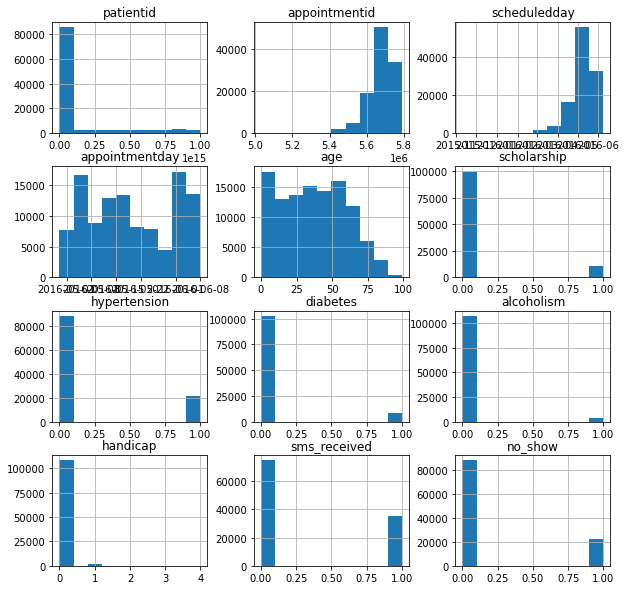

```python
df.hist(figsize=(10,10));
```

### Does gender affect if the patient will show up for scheduled appointment?

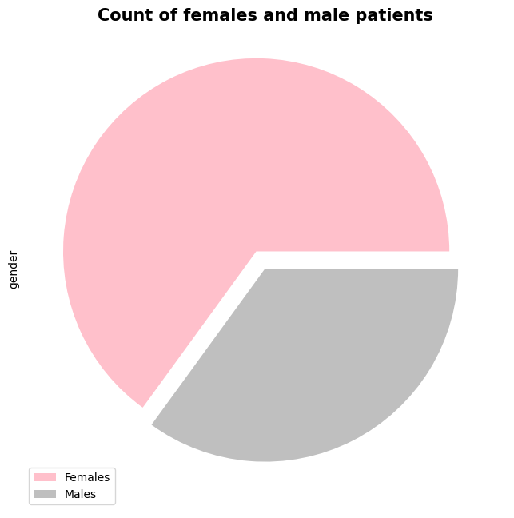

```python
plt.figure(figsize=(10,8), dpi = 100)

labels = ['Females', 'Males']

# Plot pie chart
df.gender.value_counts().plot.pie(labels= labels, explode= [0.1, 0], colors= ['pink', '0.75'],
                                  textprops= dict(color='white'))

# Plot title and legend
plt.title('Count of females and male patients', fontsize= 15, fontweight= 'bold')
plt.legend(labels, loc= 0)

plt.show()
```

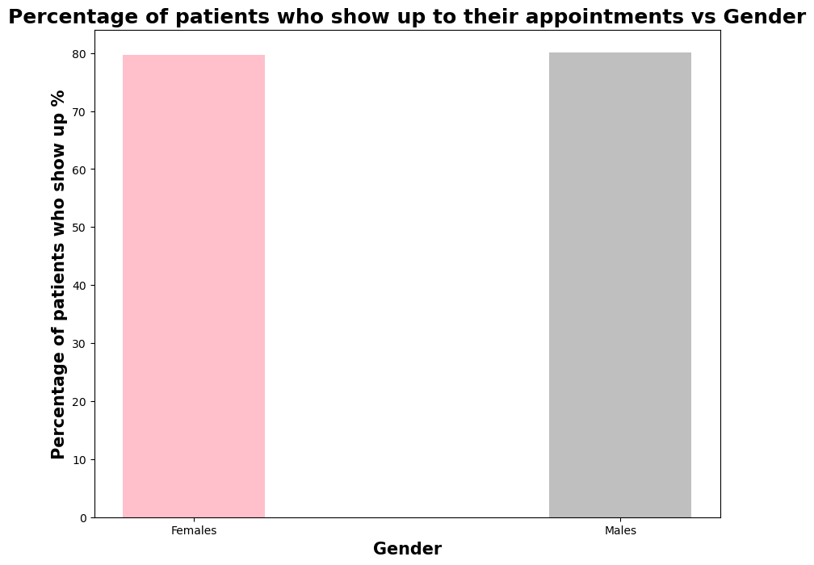

```python
x = get_percentage(df, 'gender')

# Percentages of males and females that showed up to their appointments
show_gender = x.loc[0]
female_show = show_gender.loc['F']
male_show = show_gender.loc['M']

plt.figure(figsize=(10,8), dpi=100)

# width of each bar
width = 0.2

plt.bar(0, female_show, width, color= 'pink', label= 'Females')
plt.bar(0.6, male_show, width, color= '0.75', label='Males')

plt.xticks([0,0.6], ['Females', 'Males'])
plt.title('Percentage of patients who show up to their appointments vs Gender', fontsize= 18, fontweight ='bold')
plt.xlabel('Gender', fontsize= 15, fontweight ='bold')
plt.ylabel('Percentage of patients who show up %', fontsize= 15, fontweight ='bold')

plt.show()
```

**Conclusion:**  
*Gender has no relation with whether the patient will show up or not*

### Does patients who wait less for their appointments show up to their appointments more?

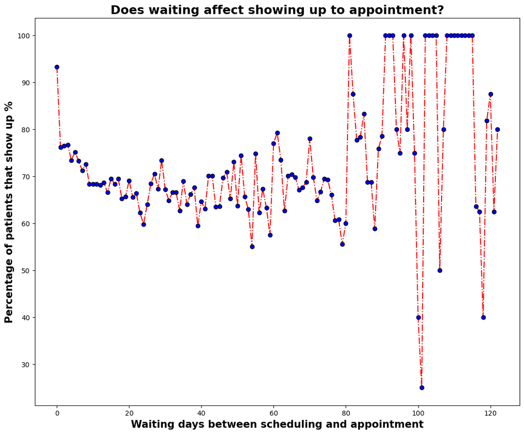

```python
df['waiting_days'] = (df['appointmentday'] - df['scheduledday']).dt.days

# disable warning that occurs when I change the waiting_days of -1 to 0
pd.options.mode.chained_assignment = None  # default='warn

# Change the value of waiting_days that are below zero to zero
df['waiting_days'][df.waiting_days < 0] = 0

x = get_percentage(df, 'waiting_days')
show_wait = x.loc[0]

ind = np.arange(len(show_wait))

fig_1 = plt.figure(figsize=(10,8), dpi = 100)
axes_1 = fig_1.add_axes([0,0,1,1])

axes_1.plot(ind, show_wait,color = 'red', marker= 'o', markerfacecolor = 'blue', markeredgecolor = 'k', ls = '-.')

# Display Title, xlabel, ylabel, xticks, and xticks
axes_1.set_title('Does waiting affect showing up to appointment?', fontsize = 18, fontweight = 'bold')
axes_1.set_xlabel('Waiting days between scheduling and appointment', fontsize = 15, fontweight = 'bold')
axes_1.set_ylabel('Percentage of patients that show up %', fontsize =15, fontweight = 'bold')

plt.show()
```

**Interesting**  
The percentange of patients that show up is high (>80%) when the appointment day is the same as scheduled day **(No wating time)**  
However, the percentage of patients that show up decreases to around (65%) when the patient has to wait more than 1 day up to 85 days.  
Finally, the percentage of patients that show up increases again, when the patient waits more than 85 days.  
**So what is the hypothesis for such an increase after the patients wait more than 85 days?**  
*(Is it because they receive more reminder SMS in comparison to people who wait less or is it because that there are few patients that wait more than 85 days to get to appointment?)*

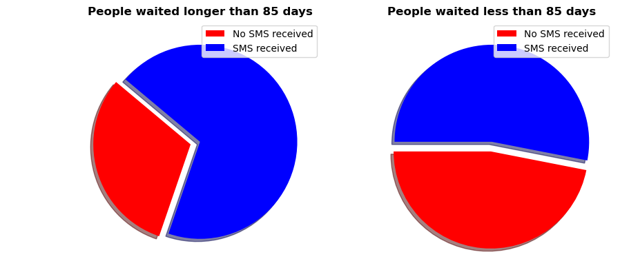

```python
fig_2, axes_2 = plt.subplots(figsize=(10,8), dpi = 100, nrows= 1, ncols= 2)

# People who waited longer than 85 days
df_wait_high = df.query('waiting_days > 85')
x = df_wait_high.groupby('sms_received').count()['gender']
labels = ['No SMS received', 'SMS received']

# Plot percentange of people who waited longer than 85 days that received and didn't receive SMS
axes_2[0].pie(x, explode= [0.1,0], labels= labels, colors= ['red', 'blue'], shadow= True,
          startangle= 140, textprops= dict(color = 'white'))
axes_2[0].legend(labels, loc = 0)
axes_2[0].set_title('People waited longer than 85 days', fontweight = 'bold')

# People who waited less than 85 days
df_wait_low = df.query('1 <= waiting_days < 85')
x = df_wait_low.groupby('sms_received').count()['gender']
labels = ['No SMS received', 'SMS received']

# Plot percentange of people who waited less than 85 days that received and didn't receive SMS
axes_2[1].pie(x, explode= [0.1,0], labels= labels, colors= ['red', 'blue'], shadow= True,
          startangle= 180, textprops= dict(color = 'white'))
axes_2[1].legend(labels, loc = 0)
axes_2[1].set_title('People waited less than 85 days', fontweight = 'bold')

plt.show()
```

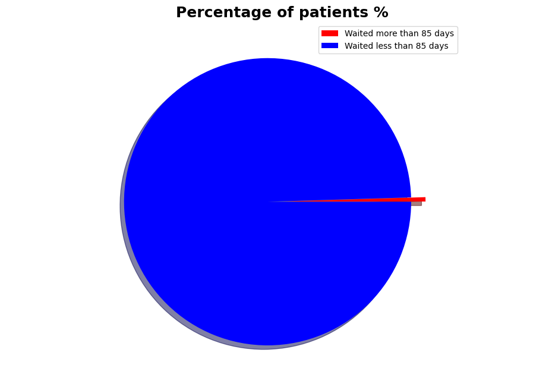

```python
# x is a list of (number of patients that waited more than 85 days, number of patients waited less than 85 days)
x = [df_wait_high.shape[0], df_wait_low.shape[0]]
labels = ['Waited more than 85 days', 'Waited less than 85 days']

plt.figure(figsize=(10,8), dpi = 100)
plt.pie(x, labels= labels, textprops=dict(color='w'), explode = [0,0.1], colors = ['red', 'blue'], shadow= True)

plt.title('Percentage of patients %', fontsize = 18, fontweight = 'bold')
plt.legend(labels, loc = 0)

plt.show()
```

Indeed patients who waited more than 85 days received more SMS in comparison to people who waited less than 85 days. **However**, patients who waited more than 85 days are very few compared to patients who waited less then 85 days.  
So, The most probable reason for such an increase in percentage of patients who (show up) after the patients wait more than 85 days is due to the fact there are very patients who actually wait more than 85 days

### Does Age affect showing up to appointment?

Age Histogram for all the patients

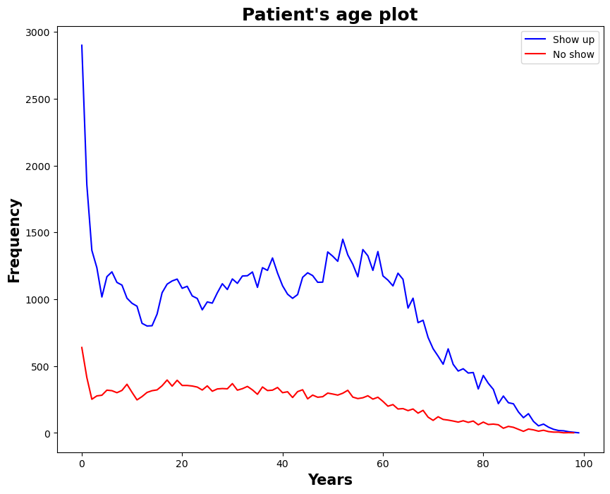

```python
x = df.groupby(['no_show', 'age']).count()['gender']

show_age = x.loc[0] # Choose no_show equals zero meaning the patient showed up
no_show_age = x.loc[1] # Choose no_show equals zero meaning the patient showed up

fig_1 = plt.figure(figsize=(10,8), dpi = 100)

plt.plot(show_age, label = 'Show up', color ='blue');
plt.plot(no_show_age, label = 'No show', color = 'red');

# plot title, xlabel, ylabel, and legend
plt.title("Patient's age plot", fontsize = 18, fontweight ='bold')
plt.xlabel('Years', fontsize = 15, fontweight ='bold')
plt.ylabel('Frequency', fontsize = 15, fontweight ='bold')
plt.legend()

plt.show()
```

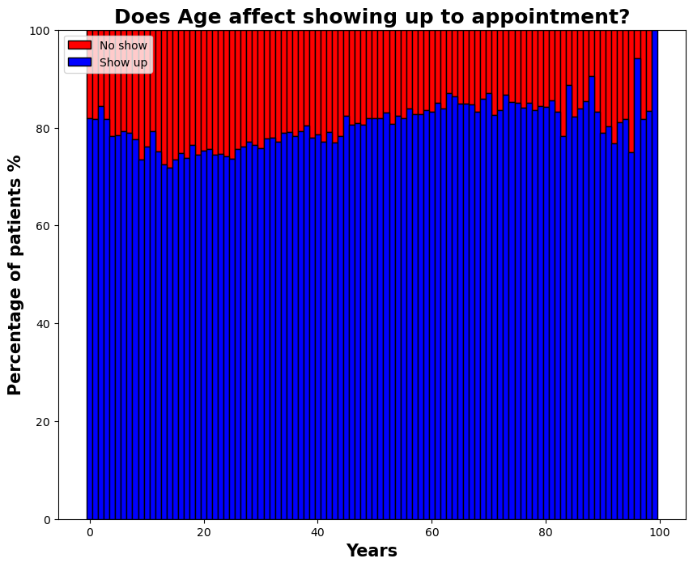

```python
x = get_percentage(df, 'age')

show_age = x[0]
no_show_age = x[1]

# for people aged 99, all of them showed up, so adding age 99 to the no_show series and give a value of 0%, so that len(show) == len(no_show)
no_show_age['99'] = 0

age = np.arange(len(show_age)) # indices for the bars (0 to 99) which corresponds to age
width = 1 # width of the bar chart

# Plot the Bar Chart
fig_2 = plt.figure(figsize=(10,8), dpi=100)

# Plot bar chart for age interval for people who didn't show up
plt.bar(age, no_show_age, width, color = 'r', edgecolor= 'k', label = 'No show', bottom = show_age)
plt.bar(age, show_age, width, color = 'b', edgecolor= 'k', label = 'Show up')

# Display Title, xlabel, ylabel, xticks, and a legend
plt.title('Does Age affect showing up to appointment?', fontsize = 18, fontweight = 'bold')
plt.xlabel('Years', fontsize = 15, fontweight = 'bold')
plt.ylabel('Percentage of patients %', fontsize =15, fontweight = 'bold')
plt.legend()



plt.show()
```

### Does being handicap affect patients to show up to doctor appointments?

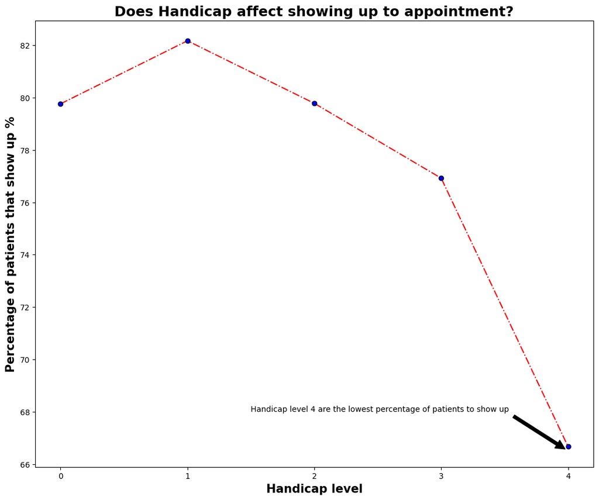

```python
column = 'handicap'
# Get the percentage of handicaped patients who show up
x = get_percentage(df, column)

show_handicap = x.loc[0]
ind = np.arange(len(show_handicap))

fig_4 = plt.figure(figsize=(10,8), dpi = 100)
axes_1 = fig_4.add_axes([0,0,1,1])

axes_1.plot(ind, show_handicap,color = 'red', marker= 'o', markerfacecolor = 'blue', markeredgecolor = 'k', ls = '-.')

axes_1.annotate('Handicap level 4 are the lowest percentage of patients to show up', xy = (4, 66.5), xytext = (1.5, 68),
                arrowprops = dict(facecolor = 'k', shrink = 0.05))

# Display Title, xlabel, ylabel, xticks, and xticks
axes_1.set_title('Does Handicap affect showing up to appointment?', fontsize = 18, fontweight = 'bold')
axes_1.set_xlabel('Handicap level', fontsize = 15, fontweight = 'bold')
axes_1.set_ylabel('Percentage of patients that show up %', fontsize =15, fontweight = 'bold')
axes_1.set_xticks([0,1,2,3,4])

plt.show()
```

**Conclusion**  
*People who are more handicapped are more likely not to show up to a doctor appointments*  
Kinda make sense, since those patients may require help from relative or a friend to show up to the doctor appointment

### What is the effect that the patient having scholarship, hypertension, diabetes may not show up to a doctor appointment?

### What is the effect that the patient being alcoholic or not receiving a reminder sms may not show up to the appointment?

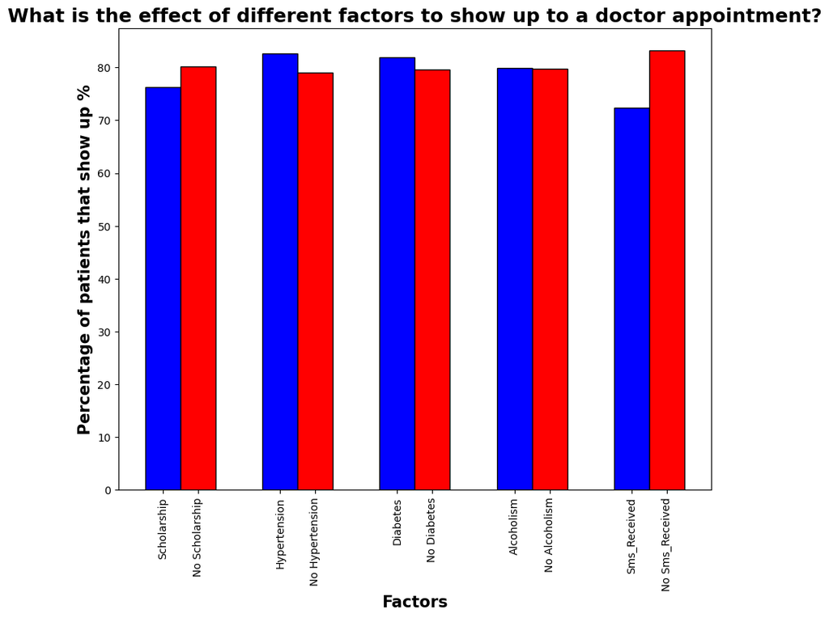

```python
columns = ['scholarship', 'hypertension', 'diabetes', 'alcoholism', 'sms_received'] # all these columns have either (0) or (1)

# Create empty list for people without certain attribute (e.g. scholarship, hypertension ... etc) and did SHOW UP
show_no_attr = []
# Create empty list for people with certain attribute (e.g. scholarship, hypertension ... etc) and did SHOW UP
show_attr = []

for column in columns:

    percentage = get_percentage(df, column)

    # people without certain attribute e.g.(without scholarship, hypertension ..etc) and did show
    show_no_attr.append(percentage.loc[0][0])

    # people with certain attribute e.g.(with scholarship, hypertension ..etc) and did show
    show_attr.append(percentage.loc[0][1])

ind = np.arange(len(show_no_attr))

width = 0.3

fig_3 = plt.figure(figsize=(10,8), dpi = 100)

# Plot bar char (people with certain attribute (e.g. with scholarship) showing who did show up and who didn't)
plt.bar(ind, show_attr, width = width, edgecolor='k', color= 'blue')

# Plot bar char (people without certain attribute (e.g. without scholarship) showing who did show up and who didn't)
plt.bar(ind+ width, show_no_attr, width = width, edgecolor= 'k', color= 'red')


# Function that add "No" before the string, used to generate of xticks_labels from column i.e. scholarship, no scholarship ...etc
function = lambda x:'No {}'.format(x).title()

# Generate xticks_labels from columns ['scholarship', 'No scholarship', 'hypertension', 'No hypertension' ... etc]
xticks_labels = [f(x) for x in columns for f in (lambda x:x.title(), function)]

# Calculate xticks_location for each bar
xticks_locations = np.concatenate((ind, ind + width))
xticks_locations.sort(kind='mergesort')

# plot title, x&y labels, xticks, and legend
plt.title('What is the effect of different factors to show up to a doctor appointment?', fontsize = 18, fontweight = 'bold')
plt.xlabel('Factors', fontsize = 15, fontweight = 'bold')
plt.ylabel('Percentage of patients that show up %', fontsize = 15, fontweight = 'bold')
plt.xticks(xticks_locations, xticks_labels, rotation = 90)


plt.show()
```

**Conclusion**  
*Patients with hypertension or diabetes show up to the doctor appointments slightly **more** than patients without hypertension or diabetes*  
*Alcohol has no effect whether the patient may show up to doctor appointments or none*  
*Interestingly patients with scholarship and patients who receive a reminder SMS show up to doctor appointments slightly **less** than patients without scholarship and didn't receive a reminder SMS*

### Limitations

1. In some patients the appointment date was set before scheduled date, which resulted that waiting time value for some patients was **-1** day, this was corrected by assuming that waiting time was zero days
2. Some age values are in negative